# 23_plr_vect_add_simp

## 23_plr_vect_add_simp

#### Question

1. A ship sailed 5.1 miles in a direction of 11° North of East. The ship turned and sailed 3.9 miles in a direction 74° North of East.

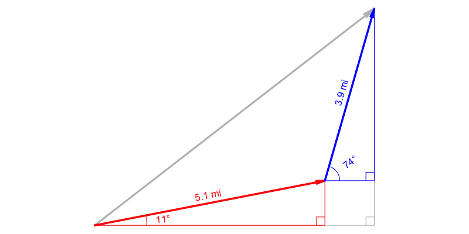

   The ship’s captain suffers a terrible accident. The first officer radios for help and sets anchor, waiting for help while administering first aid.

   A helicopter, starting where the ship started, wishes to fly directly to the ship. What direction ($\theta$ rounded to nearest degree) and distance ($r$ rounded to nearest tenth of a mile) should the helicopter fly?

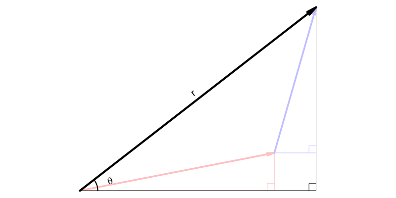

   - The direction: $\theta =$
   - The distance: $r =$

#### Question

2. A ship sailed 4.7 miles in a direction of 30° North of East. The ship turned and sailed 3.8 miles in a direction 72° North of East.

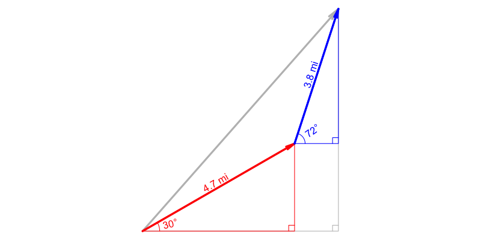

   The ship’s captain suffers a terrible accident. The first officer radios for help and sets anchor, waiting for help while administering first aid.

   A helicopter, starting where the ship started, wishes to fly directly to the ship. What direction ($\theta$ rounded to nearest degree) and distance ($r$ rounded to nearest tenth of a mile) should the helicopter fly?

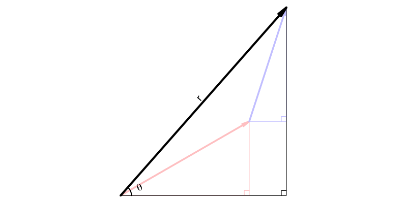

   - The direction: $\theta =$
   - The distance: $r =$

#### Question

3. A ship sailed 7.4 miles in a direction of 15° North of East. The ship turned and sailed 6.3 miles in a direction 54° North of East.

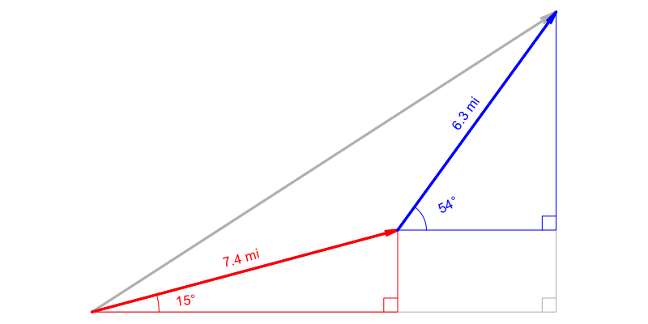

   The ship’s captain suffers a terrible accident. The first officer radios for help and sets anchor, waiting for help while administering first aid.

   A helicopter, starting where the ship started, wishes to fly directly to the ship. What direction ($\theta$ rounded to nearest degree) and distance ($r$ rounded to nearest tenth of a mile) should the helicopter fly?

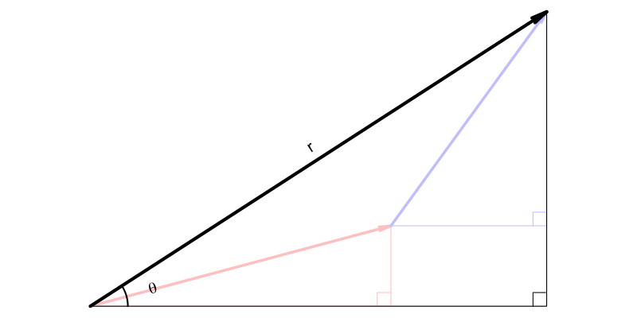

   - The direction: $\theta =$
   - The distance: $r =$

#### Question

4. A ship sailed 9.9 miles in a direction of 31° North of East. The ship turned and sailed 8.3 miles in a direction 79° North of East.

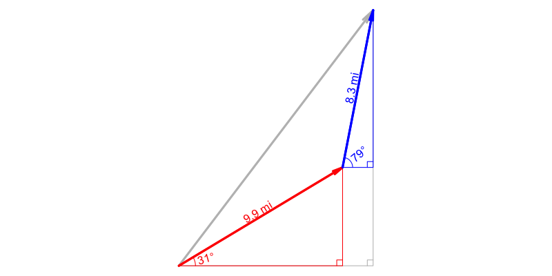

   The ship’s captain suffers a terrible accident. The first officer radios for help and sets anchor, waiting for help while administering first aid.

   A helicopter, starting where the ship started, wishes to fly directly to the ship. What direction ($\theta$ rounded to nearest degree) and distance ($r$ rounded to nearest tenth of a mile) should the helicopter fly?

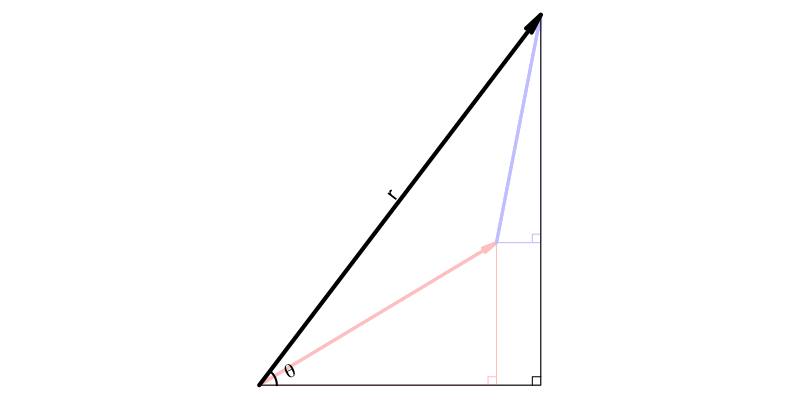

   - The direction: $\theta =$
   - The distance: $r =$

#### Question

5. A ship sailed 9.4 miles in a direction of 22° North of East. The ship turned and sailed 7.9 miles in a direction 76° North of East.

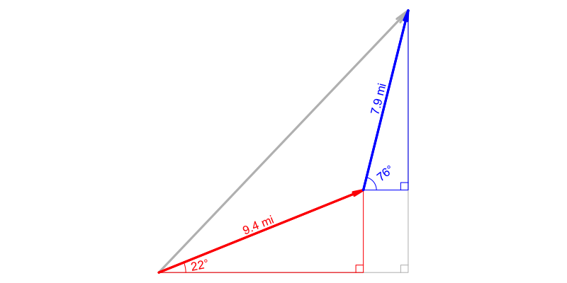

   The ship’s captain suffers a terrible accident. The first officer radios for help and sets anchor, waiting for help while administering first aid.

   A helicopter, starting where the ship started, wishes to fly directly to the ship. What direction ($\theta$ rounded to nearest degree) and distance ($r$ rounded to nearest tenth of a mile) should the helicopter fly?

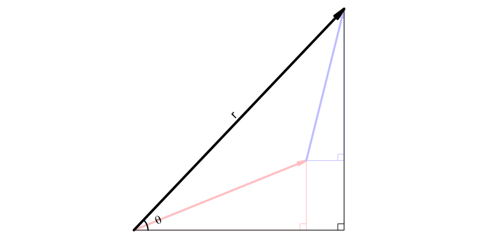

   - The direction: $\theta =$
   - The distance: $r =$

#### Question

6. A ship sailed 4.8 miles in a direction of 14° North of East. The ship turned and sailed 6.1 miles in a direction 74° North of East.

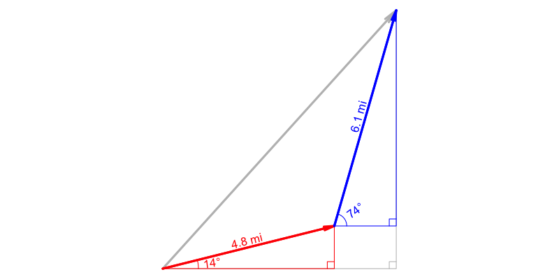

   The ship’s captain suffers a terrible accident. The first officer radios for help and sets anchor, waiting for help while administering first aid.

   A helicopter, starting where the ship started, wishes to fly directly to the ship. What direction ($\theta$ rounded to nearest degree) and distance ($r$ rounded to nearest tenth of a mile) should the helicopter fly?

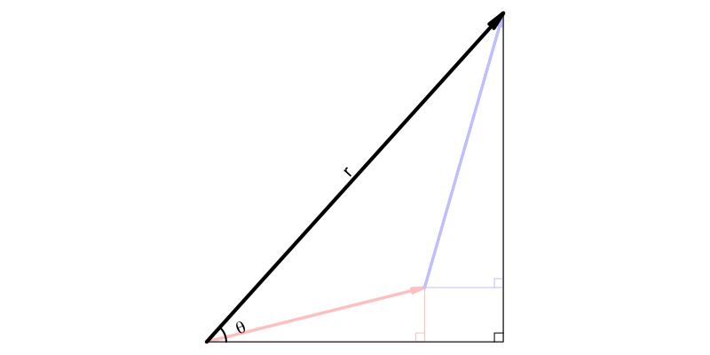

   - The direction: $\theta =$
   - The distance: $r =$

#### Question

7. A ship sailed 9.5 miles in a direction of 19° North of East. The ship turned and sailed 9.9 miles in a direction 64° North of East.

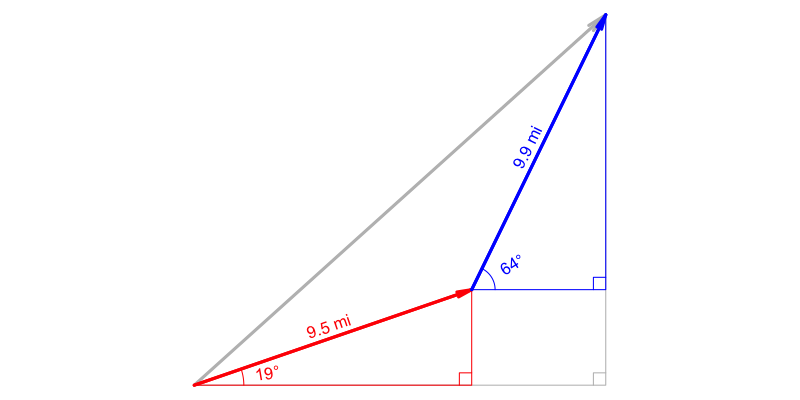

   The ship’s captain suffers a terrible accident. The first officer radios for help and sets anchor, waiting for help while administering first aid.

   A helicopter, starting where the ship started, wishes to fly directly to the ship. What direction ($\theta$ rounded to nearest degree) and distance ($r$ rounded to nearest tenth of a mile) should the helicopter fly?

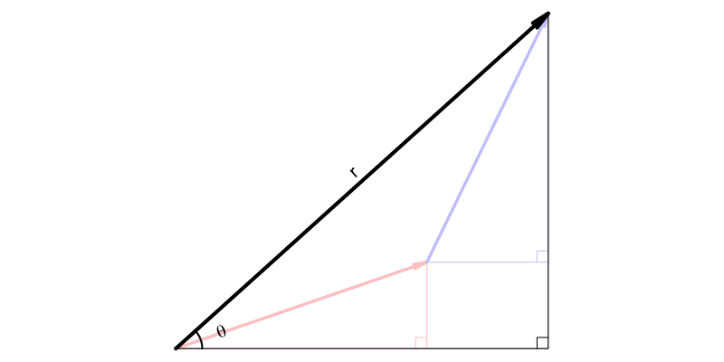

   - The direction: $\theta =$
   - The distance: $r =$

#### Question

8. A ship sailed 3.5 miles in a direction of 43° North of East. The ship turned and sailed 2.7 miles in a direction 72° North of East.

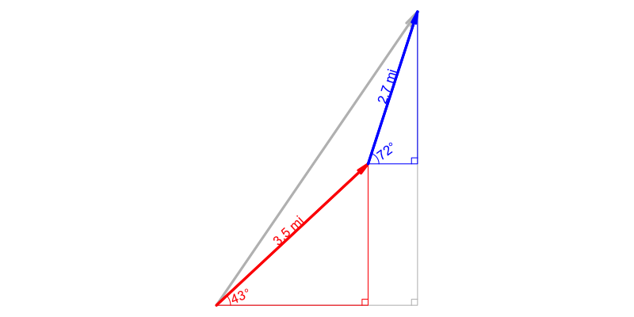

   The ship’s captain suffers a terrible accident. The first officer radios for help and sets anchor, waiting for help while administering first aid.

   A helicopter, starting where the ship started, wishes to fly directly to the ship. What direction ($\theta$ rounded to nearest degree) and distance ($r$ rounded to nearest tenth of a mile) should the helicopter fly?

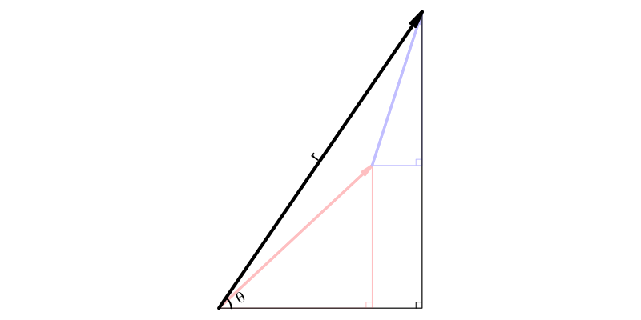

   - The direction: $\theta =$
   - The distance: $r =$